# Homework 1 - Solutions

- Show All Code
- Hide All Code

Due YYYY-MM-DD

Author

Affiliation

Alex Cardazzi

Old Dominion University

All materials can be found at [alexcardazzi.github.io](https://alexcardazzi.github.io/econ311.html).

## Question 1

What “type” of dataset (e.g. cross section, panel, etc.) are each of the following? Write your answer in bullet point form:

1. Dataset 1.a: **Panel (Traditional)**
2. Dataset 1.b: **Time Series**
3. Dataset 1.c: **Panel (Pooled Cross Section)**

Dataset 1.1

| State | Year | Value |
| --- | --- | --- |
| Connecticut | 2017 | 295.6 |
| New Jersey | 2017 | 293.7 |
| Virginia | 2017 | 223.8 |
| Connecticut | 2018 | 225.5 |
| New Jersey | 2018 | 239.1 |
| Virginia | 2018 | 234.1 |

Dataset 1.2

| State | Year | Value |
| --- | --- | --- |
| Virginia | 2006 | 245.2 |
| Virginia | 2007 | 229.0 |
| Virginia | 2008 | 245.1 |
| Virginia | 2009 | 280.7 |
| Virginia | 2010 | 260.6 |
| Virginia | 2011 | 236.3 |

Dataset 1.3

| State | Year | Value |
| --- | --- | --- |
| Connecticut | 2001 | 299.3 |
| New Jersey | 2008 | 243.1 |
| Virginia | 2010 | 212.4 |
| Virginia | 2014 | 259.4 |
| Virginia | 2017 | 221.1 |
| Virginia | 2021 | 271.0 |

## Question 2

At this point, both R and RStudio should be downloaded on your personal machine. Let’s set up a file system for this course and make sure you can connect to it via “working directories”.

1. Name your main folder `econ311`.
2. Inside this folder, make several sub-folders: `homework`, `exams`, `project`, and `scrap`.[^1]
3. Inside your homework folder, create yet another sub-folder called `homework1`.[^2]
4. Open RStudio and in the **open script** (should be `Untitled1`), use `setwd()` to set your working directory to your `econ311` folder.
5. **In the console**, execute the following code: `list.dirs(recursive = T)`
6. Take a screenshot of what you see.

**RStudio Screenshot**

[figure not shown]

Course File Structure from RStudio

## Question 3

Copy and paste the following vector into R: `vec <- sample(1:100, 10, FALSE)`

```r
# Part a.
vec <- sample(1:100, 10, FALSE)
vec # You can also do: cat("Part A:", vec)
# Part b.
vec[1:5]
# Part c.
vec[length(vec) - c(2:0)] # There are many ways to do this.
# Example: vec[8:10]; rev(vec)[1:3]
# Part d.
vec[c(3, 8)]
# Part e.
vec[vec > 50]
# Part f.
vec[vec %% 2 == 0]
```

**Output**

```
 [1]  4 48 51 80 94 13 30 95 99 23
[1]  4 48 51 80 94
[1] 95 99 23
[1] 51 95
[1] 51 80 94 95 99
[1]  4 48 80 94 30
```

## Question 4

Read in [Elderton and Pearson’s (1910) data on drinking and wages](https://vincentarelbundock.github.io/Rdatasets/csv/HistData/DrinksWages.csv) using `read.csv()` and save it as `DrinksWages`.[^3] [^4]

1. Print the column names of `DrinksWages`.
2. What type of measurement (Nominal, Ordinal, Interval, or Ratio) is `sober`? Explain why.
3. What portion of wages are larger than 30?
4. Create a new variable inside `DrinksWages` called `total` that is the sum of `sober` and `drinks`.
5. Create a new variable inside `DrinksWages` called `x` that is `drinks` divided by `x`. What is an interpretation of `x`?
6. Plot `x` on the $X$-axis and wages on the $Y$-axis. Make each `class` a different color. Use `pch = 19`. Label your axes appropriately.

```r
DrinksWages <- read.csv("https://vincentarelbundock.github.io/Rdatasets/csv/HistData/DrinksWages.csv")
# Part a.
cat("Column names of DrinksWages:\n")
```

**Output**

```
Column names of DrinksWages:
```

```r
colnames(DrinksWages); cat("\r")
```

**Output**

```
[1] "X"      "class"  "trade"  "sober"  "drinks" "wage"   "n"
```

```r
# Part b.
mean(DrinksWages$wage > 30)
```

**Output**

```
[1] 0.3285714
```

```r
# Part c.
DrinksWages$total <- DrinksWages$sober + DrinksWages$drinks
# Part d.
DrinksWages$x <- DrinksWages$drinks / DrinksWages$total
# Part e.
colors <- rep("tomato", nrow(DrinksWages))
colors[DrinksWages$class == "A"] <- "dodgerblue"
colors[DrinksWages$class == "B"] <- "orchid"
plot(DrinksWages$x, DrinksWages$wage, col = colors,
     xlab = "Fraction of Workers Who Report Drinking",
     ylab = "Wages", pch = 19, las = 1)
```

**Plot**

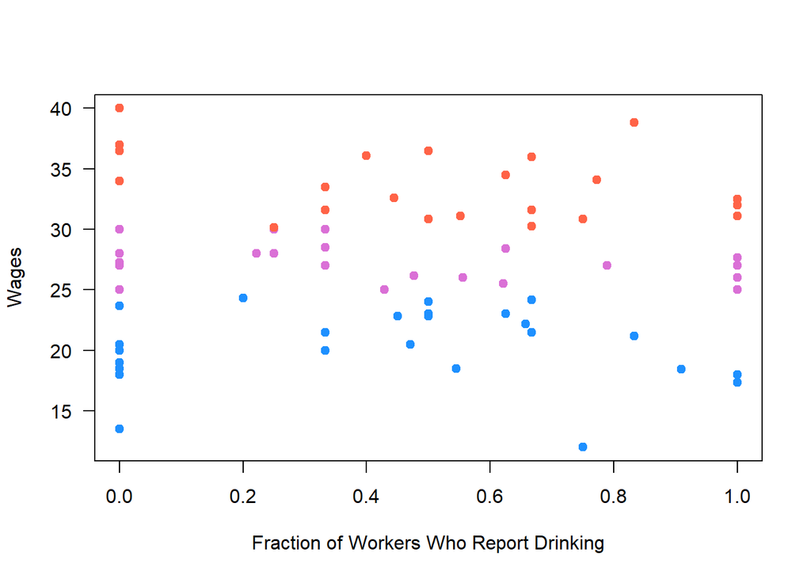

## Question 5

[This `.pdf` file](https://www.erikthered.com/tutor/historical-average-SAT-scores.pdf) contains SAT scores over time for men and women. Unfortunately, when I copied it into a `.csv`, the formatting got messed up.

1. Recreate the data in [`sat2.csv`](https://alexcardazzi.github.io/econ311/data/sat2.csv) as a `data.frame`. Rename the year and total math columns (the first one).

```r
sat2 <- read.csv("https://alexcardazzi.github.io/econ311/data/sat2.csv")
head(sat2); cat("\n\n")
```

**Output**

```
   txt
1 1952
2  ---
3  ---
4  ---
5  ---
6  ---
```

```r
# I know there are 16 columns, so let me put that into the function.
head(matrix(sat2$txt, ncol = 16)); cat("\n\n")
```

**Output**

```
     [,1]   [,2]   [,3]   [,4]   [,5]   [,6]   [,7]   [,8]   [,9]   [,10]
[1,] "1952" "---"  "\x86" "---"  "1969" "506"  "\x86" "418"  "1986" "501"
[2,] "---"  "---"  "\x86" "498"  "540"  "525"  "\x86" "466"  "509"  "521"
[3,] "---"  "---"  "477"  "---"  "536"  "489"  "429"  "492"  "515"  "483"
[4,] "---"  "\x86" "---"  "---"  "543"  "\x86" "431"  "443"  "504"  "\x86"
[5,] "---"  "\x86" "---"  "1965" "517"  "\x86" "427"  "1982" "500"  "\x86"
[6,] "---"  "\x86" "498"  "---"  "534"  "\x86" "470"  "504"  "523"  "\x86"
     [,11]  [,12]  [,13]  [,14] [,15]  [,16]
[1,] "\x86" "---"  "2003" "514" "482"  "\x86"
[2,] "\x86" "---"  "507"  "532" "496"  "\x86"
[3,] "423"  "---"  "512"  "499" "\x86" "\x86"
[4,] "425"  "---"  "503"  "493" "\x86" "\x86"
[5,] "421"  "1999" "519"  "487" "\x86" "2016"
[6,] "479"  "505"  "537"  "499" "\x86" "494"
```

```r
# That did not work.  I expected to see 1952, 1953, etc. in the first column.
# I will set "byrow = TRUE" and see what happens.
head(matrix(sat2$txt, ncol = 16, byrow = TRUE)); cat("\n\n")
```

**Output**

```
     [,1]   [,2]  [,3]  [,4]  [,5]  [,6]  [,7]  [,8]   [,9]   [,10]  [,11]
[1,] "1952" "---" "---" "---" "---" "---" "---" "\x86" "\x86" "\x86" "476"
[2,] "1953" "---" "---" "---" "---" "---" "---" "\x86" "\x86" "\x86" "476"
[3,] "1954" "---" "---" "---" "---" "---" "---" "\x86" "\x86" "\x86" "472"
[4,] "1955" "---" "---" "---" "---" "---" "---" "\x86" "\x86" "\x86" "475"
[5,] "1956" "---" "---" "---" "---" "---" "---" "\x86" "\x86" "\x86" "479"
[6,] "1957" "---" "---" "---" "---" "---" "---" "\x86" "\x86" "\x86" "473"
     [,12] [,13] [,14] [,15] [,16]
[1,] "---" "---" "494" "---" "---"
[2,] "---" "---" "495" "---" "---"
[3,] "---" "---" "490" "---" "---"
[4,] "---" "---" "496" "---" "---"
[5,] "---" "---" "501" "---" "---"
[6,] "---" "---" "496" "---" "---"
```

```r
# This appears to have worked!  Let's save the data as a data.frame.
sat_mat <- matrix(sat2$txt, ncol = 16, byrow = TRUE)
sat_df <- data.frame(sat_mat)
colnames(sat_df)[c(1, 5)] <- c("year", "total_math")
head(sat_df)
```

**Output**

```
  year  X2  X3  X4 total_math  X6  X7   X8   X9  X10 X11 X12 X13 X14 X15 X16
1 1952 --- --- ---        --- --- --- \x86 \x86 \x86 476 --- --- 494 --- ---
2 1953 --- --- ---        --- --- --- \x86 \x86 \x86 476 --- --- 495 --- ---
3 1954 --- --- ---        --- --- --- \x86 \x86 \x86 472 --- --- 490 --- ---
4 1955 --- --- ---        --- --- --- \x86 \x86 \x86 475 --- --- 496 --- ---
5 1956 --- --- ---        --- --- --- \x86 \x86 \x86 479 --- --- 501 --- ---
6 1957 --- --- ---        --- --- --- \x86 \x86 \x86 473 --- --- 496 --- ---
```

2. Make a plot where year is on the x-axis and total math is on the y-axis. Make sure to convert the total math variable to numeric. Be sure to label the axes. Color the plot where all years after 1999 are a different color than pre-2000. Be an *artist*.

```r
sat_df$total_math <- as.numeric(sat_df$total_math)
sat_df$color <- "goldenrod"
sat_df$color[sat_df$year > 1999] <- "mediumseagreen"
par(mar = c(4.1, 4.1, 1.1, 4.1)) # setting plot margins, aesthetics
plot(sat_df$year, sat_df$total_math, xlab = "Year", ylab = "Math Score",
     col = sat_df$color, las = 1, pch = 19)
```

**Plot**

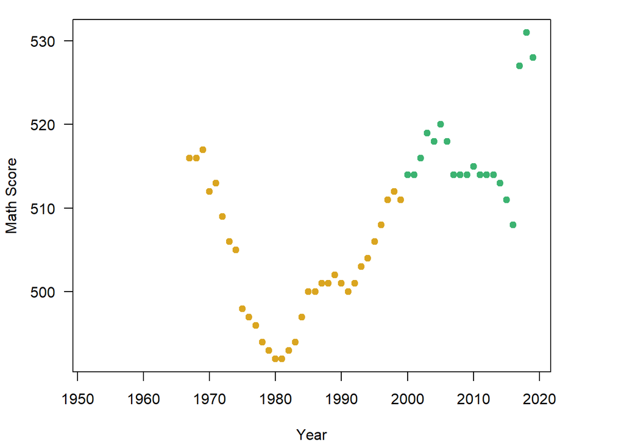

3. Remove the rows where total math is missing. Also, remove the columns between year and total math, and everything after total math.

```r
is.na(sat_df$total_math) # this tells which observations are missing
```

**Output**

```
 [1]  TRUE  TRUE  TRUE  TRUE  TRUE  TRUE  TRUE  TRUE  TRUE  TRUE  TRUE  TRUE
[13]  TRUE  TRUE  TRUE FALSE FALSE FALSE FALSE FALSE FALSE FALSE FALSE FALSE
[25] FALSE FALSE FALSE FALSE FALSE FALSE FALSE FALSE FALSE FALSE FALSE FALSE
[37] FALSE FALSE FALSE FALSE FALSE FALSE FALSE FALSE FALSE FALSE FALSE FALSE
[49] FALSE FALSE FALSE FALSE FALSE FALSE FALSE FALSE FALSE FALSE FALSE FALSE
[61] FALSE FALSE FALSE FALSE FALSE FALSE FALSE FALSE
```

```r
# Using !is.na() will tell which are NOT missing
sat_df <- sat_df[!is.na(sat_df$total_math),]
sat_df <- sat_df[,-c(2:4, 6:nrow(sat_df))] # Using the - will remove those observations
# I could have also just done: sat_df <- sat_df[,c(1, 5)]
head(sat_df)
```

**Output**

```
   year total_math
16 1967        516
17 1968        516
18 1969        517
19 1970        512
20 1971        513
21 1972        509
```

## Footnotes

[^1]: You may create other folders as well, but this is a good start for now.
[^2]: This is probably a good location to save this file (your answers)!
[^3]: Note: you can use either the hyperlink’s URL *or* you can click on the hyperlink, download the file, and read it in via file path. If you read it via file path, you should move the file so it is in your `homework1` folder.
[^4]: [The data documentation](https://vincentarelbundock.github.io/Rdatasets/doc/HistData/DrinksWages.html) might be important for understanding what each variable means.